# Interactive Socio-economic Dashboard

Alexandre Arcos Pujades

2025-02-17

[figure not shown]

# Introduction

This guide provides a step-by-step methodology for developing an **interactive socio-economic dashboard** using Shiny in R. The dashboard is designed to help local economic development practitioners and urban planners visualize and analyze key household survey data in a structured and interactive manner.

By following this guide, users will learn how to:

- Load and preprocess survey data for effective analysis.
- Build a Shiny dashboard with a dynamic user interface (UI).
- Incorporate interactive filters to explore socio-demographic trends.
- Visualize key insights using `ggplot2`, `plotly`, and `DT` tables.
- Deploy the dashboard on **shinyapps.io** for public access.

## Case Description

The fictional country of Lvneel has hired our team to analyse a survey prepared by a local NGO by interviewing a large number of households. The client wants to understand how socio-demographic variables (age, sex, marital status, ethnic group, district…) impact different quality of life indicators.

A summary of the data contained in each variable of the dataset can be found in the [Data Dictionary](https://github.com/AlexArPu/Urban-Regeneration-Project-Socio-economic-Data-Analysis-Guide/blob/d420a7a7465efcce5b863afc2a56ba47e305a8b3/Socioeconomic_Data_Dictionary.xlsx).

# Getting to Know our Data

## Loading Necessary Libraries and Dataset

This step involves loading the dataset we’ll be working with and the libraries that will allow us to manipulate and visualize the data. `tidyverse` includes several packages like `ggplot2` for plotting, and `dplyr` for data manipulation.

```r
# We load necessary libraries for data manipulation and visualization
library(tidyverse)
library(readxl)
library(shiny)
library(shinydashboard)
library(DT)
library(plotly)


# We load our dataset
hh_survey<-read_xlsx("complete_survey.xlsx")
```

## Data Preprocessing

To enhance the analysis of employment patterns in the study area, we classify individuals based on whether they work **inside or outside** the area. Since the dataset does not include exact workplace locations, we approximate this **based on respondents’ mode of transport and commute time**. This classification allows for better insights into commuting patterns, job accessibility, and spatial employment distribution—which can be useful for urban planning and transport policy discussions.

```r
# Define commute thresholds for working within the area
hh_survey <- hh_survey %>%
    mutate(work_group = case_when(
        Informant_workcommute %in% c("Company car/ bus", "Carpool with others",
                                     "Private car owned by someone else", "Private car that they own",
                                     "Uber/Careem", "Taxi") &
            Informant_commutetime <= 10 ~ "work_in",
        Informant_workcommute == "Walking" & Informant_commutetime <= 30 ~ "work_in",
        Informant_workcommute == "Cycling" & Informant_commutetime <= 12 ~ "work_in",
        Informant_workcommute == "Motorcycle" & Informant_commutetime <= 8 ~ "work_in",
        Informant_workcommute == "Public transportation" & Informant_commutetime <= 15 ~ "work_in",
        TRUE ~ "work_out"
    ))
```

# Basic Structure of the Dashboard

This section defines the core structure of the Shiny dashboard. It consists of three main components:

**User Interface (UI)** – Defines the layout and navigation of the dashboard using `dashboardPage()`. It contains:

- A **header** with the title.
- A **sidebar** that includes a **dropdown menu** to filter data by Nationality or District.
- A main content area (`dashboardBody()`) with a tabbed interface containing:
  - A **Summary** tab (for key statistics).
  - A **Charts** tab (for visualizations).
  - A **Data Table** tab (for raw data exploration).

**Server Logic** – Handles reactive behavior based on user selections.

- A **dynamic filter UI** (`output$dynamic_filter`) that updates based on whether the user chooses Nationality or District.
- A **reactive dataset** (`filtered_data`) that updates automatically when a filter is applied.

**Launching the App** – The `shinyApp(ui, server)` function runs the dashboard, allowing users to interact with the data in real time.

This foundation sets the stage for adding data visualizations, tables and statistics in the next steps.

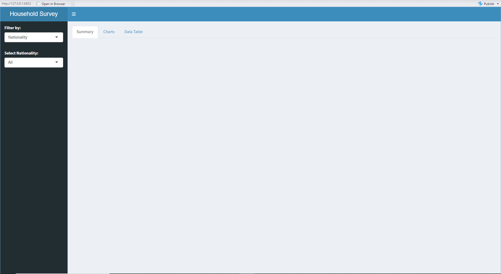

Basic Structure

```r
ui <- dashboardPage(
  dashboardHeader(title = "Household Survey Dashboard"),
  dashboardSidebar(
    selectInput("filter_type", "Filter by:", choices = c("Nationality", "District")),
    uiOutput("dynamic_filter")
  ),
  dashboardBody(
    tabsetPanel(
      tabPanel("Summary", value = "summary", fluidRow()),  # Placeholder for Summary Tab
      tabPanel("Charts", value = "charts", fluidRow()),    # Placeholder for Charts Tab
      tabPanel("Data Table", value = "table", fluidRow())  # Placeholder for Data Table Tab
    )
  )
)

# Define server logic
server <- function(input, output, session) {

  # Dynamic filter UI
  output$dynamic_filter <- renderUI({
    if (input$filter_type == "Nationality") {
      selectInput("selected_filter", "Select Nationality:",
                  choices = c("All", unique(hh_survey$Informant_nationality)),
                  selected = "All")
    } else {
      selectInput("selected_filter", "Select District:",
                  choices = c("Lvneel", unique(hh_survey$District)),
                  selected = "Lvneel")
    }
  })

  # Reactive dataset based on filter selection
  filtered_data <- reactive({
    if (input$filter_type == "Nationality") {
      if (input$selected_filter == "All") {
        hh_survey  # No filtering
      } else {
        hh_survey %>% filter(Informant_nationality == input$selected_filter)
      }
    } else {
      if (input$selected_filter == "Lvneel") {
        hh_survey  # No filtering
      } else {
        hh_survey %>% filter(District == input$selected_filter)
      }
    }
  })

}

# Run the app
shinyApp(ui, server)
```

# Adding the Summary Tab

In this step, we introduce the **Summary tab**, which presents key indicators in a clear and structured format using `infoBox()`. This component provides a quick overview of important socio-economic statistics derived from the survey data.

## Enhancements in this Step

- **Implementation of `infoBoxOutput()`**: Each key indicator is displayed in a separate information box.
- **Integration of Dynamic Filtering**: The displayed statistics adjust based on user-selected Nationality or District.
- **Application of Custom Styling**: CSS modifications ensure that numbers are larger and more readable.

## New Functionalities Introduced

1. **Displaying Key Indicators**
   - `infoBoxOutput()` elements are added to the UI, each corresponding to a specific statistic.
   - `renderInfoBox()` functions in the server compute the relevant values dynamically.
2. **Dynamic Computation of Summary Statistics**
   - The mean or percentage is calculated for each metric using `mean(filtered_data()$variable, na.rm = TRUE)`.
   - Where applicable, conditions are used to count categorical responses (e.g., secondary education completion).
3. **Styling Adjustments**
   - The `.info-box-number` CSS rule increases font size for better readability.

This step ensures that users can quickly interpret high-level trends before exploring more detailed charts or raw data.

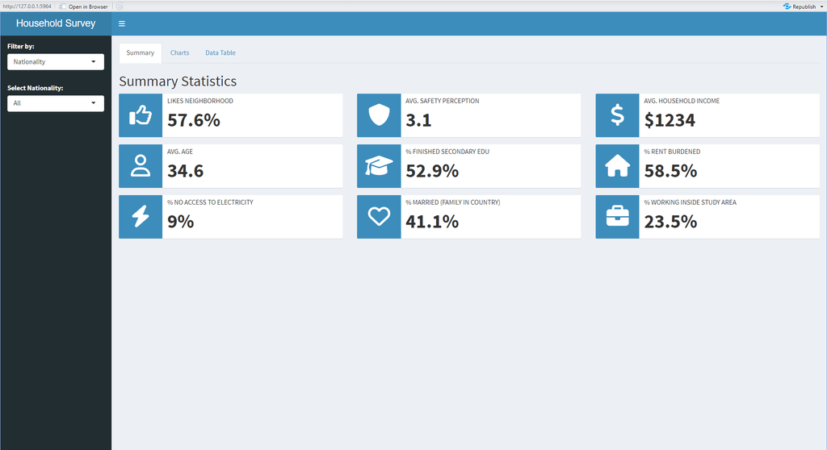

Tab 1

```r
# Define UI
ui <- dashboardPage(
    dashboardHeader(title = "Household Survey Dashboard"),
    dashboardSidebar(
        selectInput("filter_type", "Filter by:", choices = c("Nationality", "District")),
        uiOutput("dynamic_filter")
    ),
    dashboardBody(
        tags$head(tags$style(HTML("
            .info-box-number {
                font-size: 40px !important;   /* Bigger numbers */
            }
        "))),
        tabsetPanel(
            tabPanel("Summary",
                     fluidRow(column(12, h2("Summary Statistics"))),
                     fluidRow(infoBoxOutput("neigh_like"),
                              infoBoxOutput("safety_perception"),
                              infoBoxOutput("hh_income")),
                     fluidRow(infoBoxOutput("avg_age"),
                              infoBoxOutput("secondary_edu"),
                              infoBoxOutput("unaffordable_rent")),
                     fluidRow(infoBoxOutput("no_electricity"),
                              infoBoxOutput("married_in_country"),
                              infoBoxOutput("work_inside_area"))
            ),
            tabPanel("Charts", fluidRow()),
            tabPanel("Data Table", fluidRow())
        )
    )
)

# Define server logic
server <- function(input, output, session) {

    # Dynamic filter UI
    output$dynamic_filter <- renderUI({
        if (input$filter_type == "Nationality") {
            selectInput("selected_filter", "Select Nationality:",
                        choices = c("All", unique(hh_survey$Informant_nationality)),
                        selected = "All")
        } else {
            selectInput("selected_filter", "Select District:",
                        choices = c("Lvneel", unique(hh_survey$District)),
                        selected = "Lvneel")
        }
    })

    # Reactive dataset based on filter selection
    filtered_data <- reactive({
        if (input$filter_type == "Nationality") {
            if (input$selected_filter == "All") {
                hh_survey
            } else {
                hh_survey %>% filter(Informant_nationality == input$selected_filter)
            }
        } else {
            if (input$selected_filter == "Lvneel") {
                hh_survey
            } else {
                hh_survey %>% filter(District == input$selected_filter)
            }
        }
    })

    # Summary Statistics Computation
    output$neigh_like <- renderInfoBox({
        value <- mean(filtered_data()$Neighlike_Binary, na.rm = TRUE) * 100
        infoBox("Likes Neighborhood", paste0(round(value, 1), "%"), icon = icon("thumbs-up"),
                color = "light-blue")
    })

    output$safety_perception <- renderInfoBox({
        value <- mean(filtered_data()$NeighSafety, na.rm = TRUE)
        infoBox("Avg. Safety Perception", round(value, 1), icon = icon("shield"),
                color = "light-blue")
    })

    output$hh_income <- renderInfoBox({
        value <- mean(filtered_data()$hh_income, na.rm = TRUE)
        infoBox("Avg. Household Income", paste0("$", round(value, 0)), icon = icon("dollar-sign"),
                color = "light-blue")
    })

    output$avg_age <- renderInfoBox({
        value <- mean(filtered_data()$InformantAge, na.rm = TRUE)
        infoBox("Avg. Age", round(value, 1), icon = icon("user"),
                color = "light-blue")
    })

    output$secondary_edu <- renderInfoBox({
        value <- mean(filtered_data()$Informant_edulevel %in%
                          c("Secondary school completed (10th to 12th grade)",
                            "College/University completed",
                            "Diploma (technical/vocational training)",
                            "Masters/high diploma completed",
                            "Doctorate completed"), na.rm = TRUE) * 100
        infoBox("% Finished Secondary Edu", paste0(round(value, 1), "%"), icon = icon("graduation-cap"),
                color = "light-blue")
    })

    output$unaffordable_rent <- renderInfoBox({
        value <- mean((filtered_data()$AnnualRent / 12) / filtered_data()$hh_income > 0.3, na.rm = TRUE) * 100
        infoBox("% Rent Burdened", paste0(round(value, 1), "%"), icon = icon("home"),
                color = "light-blue")
    })

    output$no_electricity <- renderInfoBox({
    value <- mean(is.na(filtered_data()$Utility_electricity_available)) * 100
    infoBox("% No Access to Electricity", paste0(round(value, 2), "%"), icon = icon("bolt"),
            color = "light-blue")
  })

    output$married_in_country <- renderInfoBox({
        value <- mean(filtered_data()$marital_status_group == "married_family_in", na.rm = TRUE) * 100
        infoBox("% Married (Family in Country)", paste0(round(value, 1), "%"), icon = icon("heart"),
                color = "light-blue")
    })

    output$work_inside_area <- renderInfoBox({
        value <- mean(filtered_data()$work_group == "work_in", na.rm = TRUE) * 100
        infoBox("% Working Inside Study Area", paste0(round(value, 1), "%"), icon = icon("briefcase"),
                color = "light-blue")
    })
}

# Run the app
shinyApp(ui, server)
```

# Adding the Chart Tab

This section of the dashboard focuses on visualizing key socio-economic data collected in the household survey. The goal is to present distributions and segmentations of the population in an intuitive manner. The charts included in this section provide insights into age distribution, income levels, marital status, educational attainment, transport modes, access to utilities, and economic activity.

## Summary of Visualizations:

Each chart is dynamically filtered based on nationality or district, allowing users to explore differences between demographic groups. Colors have been customized for clarity and to align with best practices in data visualization.

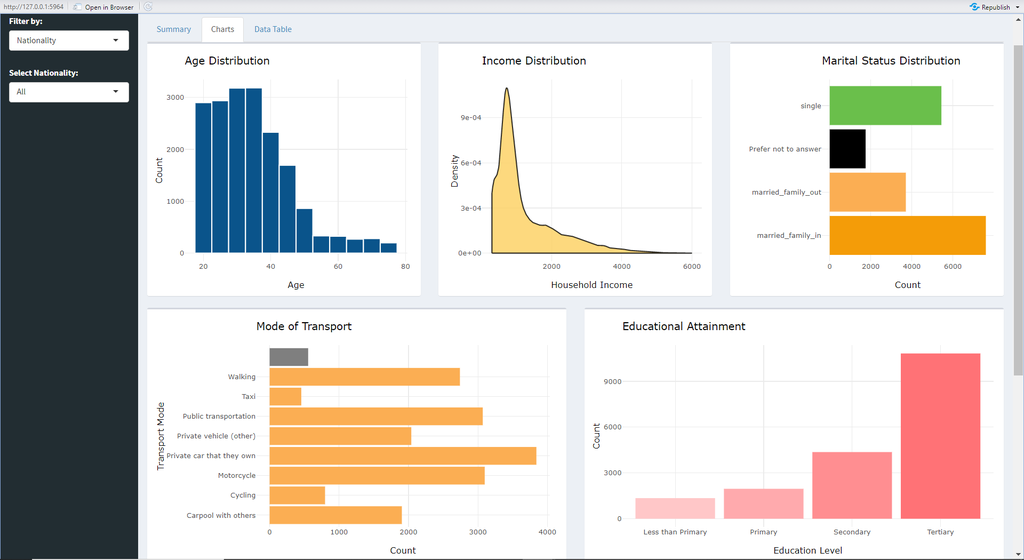

Tab 2

```r
# Define UI
ui <- dashboardPage(
    dashboardHeader(title = "Household Survey Dashboard"),
    dashboardSidebar(
        selectInput("filter_type", "Filter by:", choices = c("Nationality", "District")),
        uiOutput("dynamic_filter")
    ),
    dashboardBody(
        tabsetPanel(
            tabPanel("Summary", fluidRow()),
            tabPanel("Charts",
                     fluidRow(
                         box(plotlyOutput("age_distribution"), width = 4),
                         box(plotlyOutput("income_distribution"), width = 4),
                         box(plotlyOutput("marital_status"), width = 4)
                     ),
                     fluidRow(
                         box(plotlyOutput("mode_of_transport"), width = 6),
                         box(plotlyOutput("education_attainment"), width = 6)
                     ),
                     fluidRow(
                         box(plotlyOutput("utilities_access"), width = 6),
                         box(plotlyOutput("economic_activity"), width = 6)
                     )
            ),
            tabPanel("Data Table", fluidRow())
        )
    )
)

# Define Server
server <- function(input, output, session) {

    output$dynamic_filter <- renderUI({
        if (input$filter_type == "Nationality") {
            selectInput("selected_filter", "Select Nationality:",
                        choices = c("All", unique(hh_survey$Informant_nationality)),
                        selected = "All")
        } else {
            selectInput("selected_filter", "Select District:",
                        choices = c("Lvneel", unique(hh_survey$District)),
                        selected = "Lvneel")
        }
    })

    filtered_data <- reactive({
        if (input$filter_type == "Nationality") {
            if (input$selected_filter == "All") {
                hh_survey
            } else {
                hh_survey %>% filter(Informant_nationality == input$selected_filter)
            }
        } else {
            if (input$selected_filter == "Lvneel") {
                hh_survey
            } else {
                hh_survey %>% filter(District == input$selected_filter)
            }
        }
    })

    output$age_distribution <- renderPlotly({
        ggplot(filtered_data(), aes(x = InformantAge)) +
            geom_histogram(binwidth = 5, fill = "#0A548B", color = "white") +
            labs(title = "Age Distribution", x = "Age", y = "Count") +
            theme_minimal()
    })

    output$income_distribution <- renderPlotly({
        ggplot(filtered_data(), aes(x = hh_income)) +
            geom_density(fill = "#FDD05E", alpha = 0.8) +
            labs(title = "Income Distribution", x = "Household Income", y = "Density") +
            theme_minimal()
    })

    output$marital_status <- renderPlotly({
        marital_data <- filtered_data() %>% count(marital_status_group, name = "count")

        ggplot(marital_data, aes(y = marital_status_group, x = count, fill = marital_status_group)) +
            geom_bar(stat = "identity") +
            labs(title = "Marital Status Distribution", x = "Count", y = "") +
            theme_minimal() +
            theme(legend.position = "none") +
            scale_fill_manual(values = c("married_family_in" = "#F49C08",
                                         "married_family_out" = "#FBAE53",
                                         "single" = "#6ABF4B",
                                         "Prefer not to answer" = "black"))
    })

    output$education_attainment <- renderPlotly({
        grouped_edu <- filtered_data() %>%
            mutate(education_group = case_when(
                Informant_edulevel %in% c("Less than primary school", "No formal schooling (cannot read and write)") ~ "Less than Primary",
                Informant_edulevel %in% c("Primary school completed (first to 6th grade)") ~ "Primary",
                Informant_edulevel %in% c("Secondary school completed (10th to 12th grade)") ~ "Secondary",
                TRUE ~ "Tertiary"
            )) %>%
            count(education_group)

        ggplot(grouped_edu, aes(x = education_group, y = n, fill = education_group)) +
            geom_bar(stat = "identity") +
            labs(title = "Educational Attainment", x = "Education Level", y = "Count") +
            theme_minimal() +
            theme(legend.position = "none") +
            scale_fill_manual(values = c("Tertiary" = "#FF7276", "Secondary" = "#FF8E91", "Primary" = "#FFAAAD", "Less than Primary" = "#FFC7C8"))
    })

    output$mode_of_transport <- renderPlotly({
        short_transport <- filtered_data() %>%
            mutate(Short_Transport = case_when(
                Informant_workcommute == "Private vehicle owned by someone else" ~ "Private vehicle (other)",
                TRUE ~ Informant_workcommute
            )) %>%
            count(Short_Transport)

        ggplot(short_transport, aes(x = Short_Transport, y = n, fill = Short_Transport)) +
            geom_bar(stat = "identity") +
            labs(title = "Mode of Transport", x = "Transport Mode", y = "Count") +
            theme_minimal() +
            coord_flip() +
            theme(legend.position = "none") +
            scale_fill_manual(values = rep("#FBAE53", length(unique(short_transport$Short_Transport))))
    })

    output$utilities_access <- renderPlotly({
        utilities_long <- filtered_data() %>%
            summarise(
                No_Electricity = mean(is.na(Utility_electricity_available) | Utility_electricity_available == "", na.rm = TRUE) * 100,
                No_Water = mean(is.na(Utility_water_available) | Utility_water_available == "", na.rm = TRUE) * 100,
                No_Sanitation = mean(is.na(Utility_sanitation_available) | Utility_sanitation_available == "", na.rm = TRUE) * 100,
                No_Internet = mean(is.na(Internet_hotspot) & is.na(Internet_WiFi), na.rm = TRUE) * 100
            ) %>%
            pivot_longer(cols = everything(), names_to = "Service", values_to = "Percentage_Lacking")

        ggplot(utilities_long, aes(x = Service, y = Percentage_Lacking, fill = Service)) +
            geom_bar(stat = "identity") +
            labs(title = "No Access to Utilities", x = "Utility", y = "Percentage") +
            theme_minimal() +
            theme(legend.position = "none") +
            scale_fill_manual(values = c("No_Electricity" = "#FEC526", "No_Water" = "#0A548B", "No_Sanitation" = "#6ABF4B", "No_Internet" = "#00AFAA"))
    })

    output$economic_activity <- renderPlotly({
        short_econ <- filtered_data() %>%
            mutate(Short_Econ_Activity = case_when(
                Informant_econactivity == "Agriculture, Forestry, and Fishing" ~ "Agriculture",
                Informant_econactivity == "Information and Communication Technology (ICT)" ~ "ICT",
                Informant_econactivity == "Retail and Wholesale Trade" ~ "Retail & Trade",
                TRUE ~ Informant_econactivity
            )) %>%
            count(Short_Econ_Activity)

        ggplot(short_econ, aes(y = Short_Econ_Activity, x = n, fill = Short_Econ_Activity)) +
            geom_bar(stat = "identity") +
            labs(title = "Economic Activity Distribution", x = "Count", y = "") +
            theme_minimal() +
            theme(legend.position = "none") +
            scale_fill_manual(values = rep("#88CC6F", length(unique(short_econ$Short_Econ_Activity))))
    })
}

# Run the app
shinyApp(ui, server)
```

# Adding the Data Table Tab

This section of the dashboard introduces an interactive **data table** that allows users to explore and analyze key summary statistics derived from the household survey dataset. The table provides a structured overview of demographic and economic indicators, enabling a detailed comparison between different **districts** or **nationality groups**.

## Features of the Data Table:

1. **Dynamic Filtering:**
   - Users can filter data **by district or nationality**, dynamically updating the displayed statistics.
2. **Key Summary Metrics:**
   - **Count:** Number of survey respondents per group.
   - **Avg. Age:** The mean age of respondents.
   - **Avg. Household Income:** The mean income reported by surveyed households.
   - **No Access to Electricity:** A proxy measure of the accessibility to basic services.
   - **Percentage Finished Secondary Education:** Proportion of respondents who completed at least secondary education.
   - **Avg. Safety Perception:** The average perception of neighborhood safety, based on survey responses.
   - **Percentage of Rent-Burdened Households:** Share of respondents spending more than **30%** of their income on rent.
   - **Percentage Working Inside Study Area:** Share of respondents who work within the area.
   - **No Access to Electricity:** Percentage of respondents **without access** to electricity.
3. **Downloadable Data:**
   - Users can **export** the table data to a **CSV file** for further analysis.

## Enhancements in this Step:

This functionality provides users with a **flexible** and **interactive** way to explore patterns in the survey data, aiding in urban planning and socio-economic research.

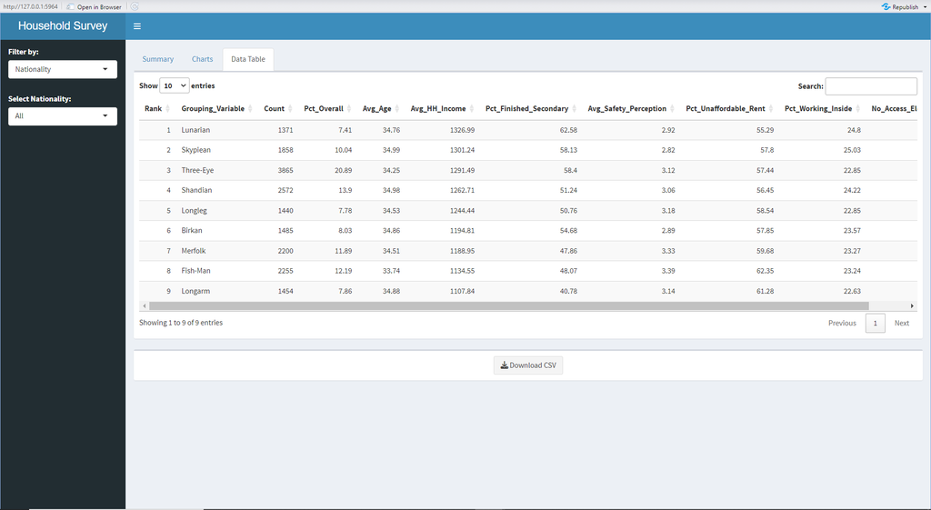

Tab 3

```r
# Define UI
ui <- dashboardPage(
    dashboardHeader(title = "Household Survey Dashboard"),
    dashboardSidebar(
        selectInput("filter_type", "Filter by:", choices = c("Nationality", "District")),
        uiOutput("dynamic_filter")
    ),
    dashboardBody(
        tabsetPanel(
            tabPanel("Summary", fluidRow()),
            tabPanel("Charts",
                     fluidRow(
                         box(plotlyOutput("age_distribution"), width = 4),
                         box(plotlyOutput("income_distribution"), width = 4),
                         box(plotlyOutput("marital_status"), width = 4)
                     ),
                     fluidRow(
                         box(plotlyOutput("mode_of_transport"), width = 6),
                         box(plotlyOutput("education_attainment"), width = 6)
                     ),
                     fluidRow(
                         box(plotlyOutput("utilities_access"), width = 6),
                         box(plotlyOutput("economic_activity"), width = 6)
                     )
            ),
            tabPanel("Data Table",
                     fluidRow(
                         box(DTOutput("summary_table"), width = 12),
                         box(downloadButton("download_table", "Download CSV"), width = 12, align = "center")
                     )
            )
        )
    )
)

# Define Server
server <- function(input, output, session) {

    output$dynamic_filter <- renderUI({
        if (input$filter_type == "Nationality") {
            selectInput("selected_filter", "Select Nationality:",
                        choices = c("All", unique(hh_survey$Informant_nationality)),
                        selected = "All")
        } else {
            selectInput("selected_filter", "Select District:",
                        choices = c("Lvneel", unique(hh_survey$District)),
                        selected = "Lvneel")
        }
    })

    filtered_data <- reactive({
        if (input$filter_type == "Nationality") {
            if (input$selected_filter == "All") {
                hh_survey
            } else {
                hh_survey %>% filter(Informant_nationality == input$selected_filter)
            }
        } else {
            if (input$selected_filter == "Lvneel") {
                hh_survey
            } else {
                hh_survey %>% filter(District == input$selected_filter)
            }
        }
    })

    summary_table <- reactive({
        total_counts <- nrow(hh_survey)  # Compute total sample size

        filtered_data() %>%
            group_by(Grouping_Variable = if (input$filter_type == "Nationality") Informant_nationality else District) %>%
            summarise(
                Count = n(),
                Pct_Overall = round((Count / total_counts) * 100, 2),  # Percentage over total
                Avg_Age = round(mean(InformantAge, na.rm = TRUE), 2),
                Avg_HH_Income = round(mean(hh_income, na.rm = TRUE), 2),
                Pct_Finished_Secondary = round(mean(Informant_edulevel %in%
                                                        c("Secondary school completed (10th to 12th grade)",
                                                          "College/University completed",
                                                          "Diploma (technical/vocational training)",
                                                          "Masters/high diploma completed",
                                                          "Doctorate completed"), na.rm = TRUE) * 100, 2),
                Avg_Safety_Perception = round(mean(as.numeric(NeighSafety), na.rm = TRUE), 2),
                Pct_Unaffordable_Rent = round(mean((AnnualRent / 12) / hh_income > 0.3, na.rm = TRUE) * 100, 2),
                Pct_Working_Inside = round(mean(work_group == "work_in", na.rm = TRUE) * 100, 2),
                No_Access_Electricity = round(mean(is.na(Utility_electricity_available) | Utility_electricity_available == "", na.rm = TRUE) * 100, 2),
                .groups = "drop"
            ) %>%
            arrange(desc(Avg_HH_Income)) %>%
            mutate(Rank = row_number()) %>%
            select(Rank, everything())
    })

    output$summary_table <- renderDT({
        datatable(summary_table(), options = list(pageLength = 10, scrollX = TRUE),
                  rownames = FALSE)
    })

    output$download_table <- downloadHandler(
        filename = function() { paste("summary_table_", Sys.Date(), ".csv", sep = "") },
        content = function(file) {
            write.csv(summary_table(), file, row.names = FALSE)
        }
    )
}

# Run the app
shinyApp(ui, server)
```

# Final Implementation: Household Survey Dashboard

This dashboard presents an interactive **Household Survey Dashboard**, designed to explore socio-economic data through **key summary statistics, visualizations, and an interactive data table**. It enables users to analyze household characteristics, income distribution, education levels, and urban infrastructure access by filtering data **by nationality or district**.

## Features and Functionalities:

### Dynamic Filtering Mechanism

- Users can **filter data by Nationality or District**.
- The selection updates all displayed statistics and charts in real-time.

### Summary Tab

- **Key socio-economic indicators** are displayed using `infoBox()`, including:
  - **Neighborhood Satisfaction**: Percentage of respondents who like their neighborhood.
  - **Perceived Safety**: Average perception of safety on a scale.
  - **Household Income**: Mean income of respondents.
  - **Education Levels**: Percentage of respondents who completed at least secondary education.
  - **Housing Affordability**: Percentage of households paying more than **30% of income** on rent.
  - **No Access to Electricity**: A measure of accessibility to basic services.
  - **Employment Location**: Percentage of respondents working inside the study area.

### Charts Tab

- **Data Visualizations** generated using `ggplot2` and `plotly` to provide **interactive** insights into:
  - **Age Distribution** (histogram).
  - **Income Distribution** (density plot).
  - **Marital Status** (horizontal bar chart).
  - **Mode of Transport** (bar chart).
  - **Educational Attainment** (bar chart).
  - **Access to Utilities** (electricity, water, sanitation, internet).
  - **Economic Activity Distribution** (bar chart of employment sectors).

### Data Table Tab

- Displays a **sortable and scrollable** `DT::datatable()` with key statistics grouped by **Nationality or District**.
- Allows users to **download** the summary data as a **CSV file**.

## Enhancements in the Final Version

- **Styling Adjustments**: Increased font size of key numbers in `infoBox()`.
- **Fixed District Filtering**: Ensured `"Lvneel"` is selected by default to avoid `NaN` issues.
- **Improved Data Processing**: Optimized calculations for summary statistics.
- **Better Visual Representations**: Applied customized colors and themes for enhanced readability.

## Conclusion

This **Household Survey Dashboard** provides a user-friendly interface for exploring survey data and understanding demographic and economic characteristics at a granular level. The **interactive filters, data visualizations, and exportable data tables** make it a powerful tool for policymakers, urban planners, and researchers in the field of **socio-economic analysis and urban development**.

```r
# Define UI
ui <- dashboardPage(
    dashboardHeader(title = "Household Survey Dashboard"),
    dashboardSidebar(
        selectInput("filter_type", "Filter by:", choices = c("Nationality", "District")),
        uiOutput("dynamic_filter")
    ),
    dashboardBody(
      tags$head(tags$style(HTML("
    .info-box .info-box-number {
        font-size: 40px !important;   /* Bigger numbers */
        font-weight: bold !important; /* Bold text */
    }
      "))),
        tabsetPanel(
            tabPanel("Summary",
                     fluidRow(column(12, h2("Summary Statistics"))),
                     fluidRow(infoBoxOutput("neigh_like"),
                              infoBoxOutput("safety_perception"),
                              infoBoxOutput("hh_income")),
                     fluidRow(infoBoxOutput("avg_age"),
                              infoBoxOutput("secondary_edu"),
                              infoBoxOutput("unaffordable_rent")),
                     fluidRow(infoBoxOutput("no_electricity"),
                              infoBoxOutput("married_in_country"),
                              infoBoxOutput("work_inside_area"))
            ),
            tabPanel("Charts",
                     fluidRow(
                         box(plotlyOutput("age_distribution"), width = 4),
                         box(plotlyOutput("income_distribution"), width = 4),
                         box(plotlyOutput("marital_status"), width = 4)
                     ),
                     fluidRow(
                         box(plotlyOutput("mode_of_transport"), width = 6),
                         box(plotlyOutput("education_attainment"), width = 6)
                     ),
                     fluidRow(
                         box(plotlyOutput("utilities_access"), width = 6),
                         box(plotlyOutput("economic_activity"), width = 6)
                     )
            ),
              tabPanel("Data Table",
                     fluidRow(
                         box(DTOutput("summary_table"), width = 12),
                         box(downloadButton("download_table", "Download CSV"), width = 12, align = "center")
                     )
            )
        )
    )
)

# Define Server
server <- function(input, output, session) {
    output$dynamic_filter <- renderUI({
    if (input$filter_type == "Nationality") {
        selectInput("selected_filter", "Select Nationality:",
                    choices = c("All", unique(hh_survey$Informant_nationality)),
                    selected = "All")
    } else {
        selectInput("selected_filter", "Select District:",
                    choices = c("Lvneel", unique(hh_survey$District)),
                    selected = "Lvneel")
    }
    })

    filtered_data <- reactive({
    if (input$filter_type == "Nationality") {
        if (input$selected_filter == "All") {
            hh_survey
        } else {
            hh_survey %>% filter(Informant_nationality == input$selected_filter)
        }
    } else {
        if (input$selected_filter == "Lvneel") {
            hh_survey
        } else {
            hh_survey %>% filter(District == input$selected_filter)
        }
    }
    })

    # Summary Statistics Computation
    output$neigh_like <- renderInfoBox({
        value <- mean(filtered_data()$Neighlike_Binary, na.rm = TRUE) * 100
        infoBox("Likes Neighborhood", paste0(round(value, 1), "%"), icon = icon("thumbs-up"),
                color = "light-blue")
    })

    output$safety_perception <- renderInfoBox({
        value <- mean(filtered_data()$NeighSafety, na.rm = TRUE)
        infoBox("Avg. Safety Perception", round(value, 1), icon = icon("shield"),
                color = "light-blue")
    })

    output$hh_income <- renderInfoBox({
        value <- mean(filtered_data()$hh_income, na.rm = TRUE)
        infoBox("Avg. Household Income", paste0("$", round(value, 0)), icon = icon("dollar-sign"),
                color = "light-blue")
    })

    output$avg_age <- renderInfoBox({
        value <- mean(filtered_data()$InformantAge, na.rm = TRUE)
        infoBox("Avg. Age", round(value, 1), icon = icon("user"),
                color = "light-blue")
    })

    output$secondary_edu <- renderInfoBox({
        value <- mean(filtered_data()$Informant_edulevel %in%
                          c("Secondary school completed (10th to 12th grade)",
                            "College/University completed",
                            "Diploma (technical/vocational training)",
                            "Masters/high diploma completed",
                            "Doctorate completed"), na.rm = TRUE) * 100
        infoBox("% Finished Secondary Edu", paste0(round(value, 1), "%"), icon = icon("graduation-cap"),
                color = "light-blue")
    })

    output$unaffordable_rent <- renderInfoBox({
        value <- mean((filtered_data()$AnnualRent / 12) / filtered_data()$hh_income > 0.3, na.rm = TRUE) * 100
        infoBox("% Rent Burdened", paste0(round(value, 1), "%"), icon = icon("home"),
                color = "light-blue")
    })

    output$no_electricity <- renderInfoBox({
    value <- mean(is.na(filtered_data()$Utility_electricity_available)) * 100
    infoBox("% No Access to Electricity", paste0(round(value, 2), "%"), icon = icon("bolt"),
            color = "light-blue")
  })

    output$married_in_country <- renderInfoBox({
        value <- mean(filtered_data()$marital_status_group == "married_family_in", na.rm = TRUE) * 100
        infoBox("% Married (Family in Country)", paste0(round(value, 1), "%"), icon = icon("heart"),
                color = "light-blue")
    })

    output$work_inside_area <- renderInfoBox({
        value <- mean(filtered_data()$work_group == "work_in", na.rm = TRUE) * 100
        infoBox("% Working Inside Study Area", paste0(round(value, 1), "%"), icon = icon("briefcase"),
                color = "light-blue")
    })

    # Charts
    output$age_distribution <- renderPlotly({
        ggplot(filtered_data(), aes(x = InformantAge)) +
            geom_histogram(binwidth = 5, fill = "#0A548B", color = "white") +
            labs(title = "Age Distribution", x = "Age", y = "Count") +
            theme_minimal()
    })
```

```r
    output$income_distribution <- renderPlotly({
        ggplot(filtered_data(), aes(x = hh_income)) +
            geom_density(fill = "#FDD05E", alpha = 0.8) +
            labs(title = "Income Distribution", x = "Household Income", y = "Density") +
            theme_minimal()
    })

    output$marital_status <- renderPlotly({
        marital_data <- filtered_data() %>% count(marital_status_group, name = "count")

        ggplot(marital_data, aes(y = marital_status_group, x = count, fill = marital_status_group)) +
            geom_bar(stat = "identity") +
            labs(title = "Marital Status Distribution", x = "Count", y = "") +
            theme_minimal() +
            theme(legend.position = "none") +
            scale_fill_manual(values = c("married_family_in" = "#F49C08",
                                         "married_family_out" = "#FBAE53",
                                         "single" = "#6ABF4B",
                                         "Prefer not to answer" = "black"))
    })

    output$education_attainment <- renderPlotly({
        grouped_edu <- filtered_data() %>%
            mutate(education_group = case_when(
                Informant_edulevel %in% c("Less than primary school", "No formal schooling (cannot read and write)") ~ "Less than Primary",
                Informant_edulevel %in% c("Primary school completed (first to 6th grade)") ~ "Primary",
                Informant_edulevel %in% c("Secondary school completed (10th to 12th grade)") ~ "Secondary",
                TRUE ~ "Tertiary"
            )) %>%
            count(education_group)

        ggplot(grouped_edu, aes(x = education_group, y = n, fill = education_group)) +
            geom_bar(stat = "identity") +
            labs(title = "Educational Attainment", x = "Education Level", y = "Count") +
            theme_minimal() +
            theme(legend.position = "none") +
            scale_fill_manual(values = c("Tertiary" = "#FF7276", "Secondary" = "#FF8E91", "Primary" = "#FFAAAD", "Less than Primary" = "#FFC7C8"))
    })

    output$mode_of_transport <- renderPlotly({
        short_transport <- filtered_data() %>%
            mutate(Short_Transport = case_when(
                Informant_workcommute == "Private vehicle owned by someone else" ~ "Private vehicle (other)",
                TRUE ~ Informant_workcommute
            )) %>%
            count(Short_Transport)

        ggplot(short_transport, aes(x = Short_Transport, y = n, fill = Short_Transport)) +
            geom_bar(stat = "identity") +
            labs(title = "Mode of Transport", x = "Transport Mode", y = "Count") +
            theme_minimal() +
            coord_flip() +
            theme(legend.position = "none") +
            scale_fill_manual(values = rep("#FBAE53", length(unique(short_transport$Short_Transport))))
    })

    output$utilities_access <- renderPlotly({
        utilities_long <- filtered_data() %>%
            summarise(
                No_Electricity = mean(is.na(Utility_electricity_available) | Utility_electricity_available == "", na.rm = TRUE) * 100,
                No_Water = mean(is.na(Utility_water_available) | Utility_water_available == "", na.rm = TRUE) * 100,
                No_Sanitation = mean(is.na(Utility_sanitation_available) | Utility_sanitation_available == "", na.rm = TRUE) * 100,
                No_Internet = mean(is.na(Internet_hotspot) & is.na(Internet_WiFi), na.rm = TRUE) * 100
            ) %>%
            pivot_longer(cols = everything(), names_to = "Service", values_to = "Percentage_Lacking")

        ggplot(utilities_long, aes(x = Service, y = Percentage_Lacking, fill = Service)) +
            geom_bar(stat = "identity") +
            labs(title = "No Access to Utilities", x = "Utility", y = "Percentage") +
            theme_minimal() +
            theme(legend.position = "none") +
            scale_fill_manual(values = c("No_Electricity" = "#FEC526", "No_Water" = "#0A548B", "No_Sanitation" = "#6ABF4B", "No_Internet" = "#00AFAA"))
    })

    output$economic_activity <- renderPlotly({
        short_econ <- filtered_data() %>%
            mutate(Short_Econ_Activity = case_when(
                Informant_econactivity == "Agriculture, Forestry, and Fishing" ~ "Agriculture",
                Informant_econactivity == "Information and Communication Technology (ICT)" ~ "ICT",
                Informant_econactivity == "Retail and Wholesale Trade" ~ "Retail & Trade",
                TRUE ~ Informant_econactivity
            )) %>%
            count(Short_Econ_Activity)

        ggplot(short_econ, aes(y = Short_Econ_Activity, x = n, fill = Short_Econ_Activity)) +
            geom_bar(stat = "identity") +
            labs(title = "Economic Activity Distribution", x = "Count", y = "") +
            theme_minimal() +
            theme(legend.position = "none") +
            scale_fill_manual(values = rep("#88CC6F", length(unique(short_econ$Short_Econ_Activity))))
    })
  # Table
    summary_table <- reactive({
        total_counts <- nrow(hh_survey)  # Compute total sample size

        filtered_data() %>%
            group_by(Grouping_Variable = if (input$filter_type == "Nationality") Informant_nationality else District) %>%
            summarise(
                Count = n(),
                Pct_Overall = round((Count / total_counts) * 100, 2),  # Percentage over total
                Avg_Age = round(mean(InformantAge, na.rm = TRUE), 2),
                Avg_HH_Income = round(mean(hh_income, na.rm = TRUE), 2),
                Pct_Finished_Secondary = round(mean(Informant_edulevel %in%
                                                        c("Secondary school completed (10th to 12th grade)",
                                                          "College/University completed",
                                                          "Diploma (technical/vocational training)",
                                                          "Masters/high diploma completed",
                                                          "Doctorate completed"), na.rm = TRUE) * 100, 2),
                Avg_Safety_Perception = round(mean(as.numeric(NeighSafety), na.rm = TRUE), 2),
                Pct_Unaffordable_Rent = round(mean((AnnualRent / 12) / hh_income > 0.3, na.rm = TRUE) * 100, 2),
                Pct_Working_Inside = round(mean(work_group == "work_in", na.rm = TRUE) * 100, 2),
                No_Access_Electricity = round(mean(is.na(Utility_electricity_available) | Utility_electricity_available == "", na.rm = TRUE) * 100, 2),
                .groups = "drop"
            ) %>%
            arrange(desc(Avg_HH_Income)) %>%
            mutate(Rank = row_number()) %>%
            select(Rank, everything())
    })
```

```r
    output$summary_table <- renderDT({
        datatable(summary_table(), options = list(pageLength = 10, scrollX = TRUE),
                  rownames = FALSE)
    })

    output$download_table <- downloadHandler(
        filename = function() { paste("summary_table_", Sys.Date(), ".csv", sep = "") },
        content = function(file) {
            write.csv(summary_table(), file, row.names = FALSE)
        }
    )
}

# Run the app
shinyApp(ui, server)
```

# Deploying a Shiny App to shinyapps.io

Lastly, we’ll see how to upload our work to the web.

1. Before deploying, we ensure the `rsconnect` package is installed.
2. Then we go to shinyapps.io and we sign up for an account (you can use your Google or GitHub account). After signing up, we go to Dashboard → Account Settings. Under Tokens, we click Show Secret and copy our authentication command. 3.We run the authentication command from shinyapps.io, which looks like this:

```r
rsconnect::setAccountInfo(name='your_username',
                          token='your_token',
                          secret='your_secret')
```

4. We make sure R is working in the correct directory where the app.R file (or ui.R & server.R) is located:

```r
setwd("C:/path/to/your/shiny/app")
```

5. Then we run the following command to upload our app:

```r
rsconnect::deployApp()
```

After doing this and if the deployment has been successful, you should be able to see your fully operating dashboard in your shinyapps.io account.

You can find our socio-economic dashboard uploaded [here](https://alarpu.shinyapps.io/se-dashboard/).